# Linear Models Project — M1 (2025–2026)

Determinants of Students’ Exam Performance

Boudia Merad Ambrine, Meziane Liticia and Talata Yasmine

# 1 Introduction

First of all, students’ academic performance is an important issue in education, as it influences future educational and labor market outcomes.

When studying academic performance, it is common to observe strong relationships between students’ exam scores and a wide range of individual or contextual characteristics. For instance, students who study more or attend classes more regularly often achieve better results. However, observing such relationships does not automatically imply a causal link, as several unobserved factors may simultaneously affect both study behavior and exam performance.

This project focuses on identifying and describing the main factors associated with students’ exam scores, rather than establishing strict causal relationships. Using a dataset that combines exam results with demographic characteristics, study habits, and school-related variables, we rely on linear regression models to analyze how these factors are related to academic performance.

The analysis is carried out in several steps. First, the dataset is prepared and cleaned to ensure consistent coding of the variables. We then use exploratory data analysis to better understand the data and to guide the choice of model specifications. In a next step, several linear regression models are estimated and compared. After estimation, we check the behavior of residuals and basic diagnostics to assess whether the models are appropriate. Finally, we evaluate predictive performance using a simple validation approach.

# 2 Data and Methods

## 2.1 Dataset Management

The first step of the analysis consists in **preparing and cleaning** the dataset.After importing the raw data, one starts by checking its structure and size to gain knowledge of the available information. Plus, before starting the analysis, one insures that each student appears only once in the dataset by verifying **the absence of duplicated identifiers**. Indeed if a student appears twice or more, this student carries more weight in the regression, which obviously biases the estimated coefficients that means **unreliable results** !

```r
any(duplicated(data_raw))
```

```
## [1] FALSE
```

We also check : -the possible missing values

```r
colSums(is.na(data_raw))
```

```
##             id              y            age         agecat           sexe
##              0              0              0              0              0
##    school_type    parent_educ      study_hrs      sleep_hrs     sleep_qual
##              0              0              0              0              0
##     attend_pct attend_pct_cat     web_access      trav_time      extra_act
##              0              0              0              0              0
##   study_method
##              0
```

-if our variables has plausible ranges. For example, we can observe that the age is between 14 and 19 which is consistent with the fact that the data comes from students. We also note that the study and sleep hours are quite realistic. For example, sleep time does not exceed 10 hours, which is perfectly reasonable.

```r
data.frame(
  Variable = c("y", "age", "study_hrs", "sleep_hrs", "attend_pct"),
  Min = c(min(data_raw$y), min(data_raw$age), min(data_raw$study_hrs),
          min(data_raw$sleep_hrs), min(data_raw$attend_pct)),
  Max = c(max(data_raw$y), max(data_raw$age), max(data_raw$study_hrs),
          max(data_raw$sleep_hrs), max(data_raw$attend_pct))
)
```

| Variable | Min | Max |
| --- | --- | --- |
| y | 8.9 | 99.8 |
| age | 14.0 | 19.0 |
| study_hrs | 2.0 | 14.0 |
| sleep_hrs | 4.0 | 10.0 |
| attend_pct | 50.0 | 99.9 |

-the possible outliers

```r
boxplot.stats(data_raw$y)$out
```

```
## [1] 10.6 99.8 98.0 97.3  8.9 98.9 13.0 97.2 13.0
```

```r
boxplot.stats(data_raw$age)$out
```

```
## numeric(0)
```

Furthermore , binary variables, such as web access and participation in extracurricular activities, are recoded into simple Yes/No indicators. Study methods are also transformed into a categorical variable distinguishing between different learning strategies used by students. Finally, some redundant categorical variables are **removed to avoid unnecessary duplication of information**. Eventually, one checks the **structure and dimensions** of the cleaned dataset using str() and dim() to make sure all variables were correctly coded. The data is now ready for analysis.

```r
data_clean <- data_raw %>%
  mutate(
    sexe = factor(sexe,
                  levels = c(1, 2, 3),
                  labels = c("Female", "Male", "Other")),

    school_type = factor(school_type,
                         levels = c(1, 2),
                         labels = c("Public", "Private")),

    parent_educ = factor(parent_educ,
                         levels = 1:6,
                         labels = c("No Formal",
                                    "High School",
                                    "Graduate",
                                    "Post Graduate 1",
                                    "Post Graduate 2",
                                    "PHD"),
                         ordered = FALSE),

    sleep_qual = factor(sleep_qual,
                        levels = c(1, 2, 3),
                        labels = c("Poor", "Average", "Good"),
                        ordered = FALSE),

    web_access = factor(web_access,
                        levels = c(1, 2),
                        labels = c("No", "Yes")),

    trav_time = factor(trav_time,
                       levels = c(1, 2, 3, 4),
                       labels = c("<15 Min", "15-30 Min", "30-60 Min", ">60 Min"),
                       ordered = FALSE),

    extra_act = factor(extra_act,
                       levels = c(1, 2),
                       labels = c("No", "Yes")),

    study_method = factor(study_method,
                          levels = 1:6,
                          labels = c("Online Videos",
                                     "Coaching",
                                     "Notes",
                                     "Textbook",
                                     "Group Study",
                                     "Mixed"))
  ) %>%
  select(-agecat, -attend_pct_cat)
```

## 2.2 Modeling Strategy

Not surprisingly, the analysis of students’ exam performance relies on linear regression models. Here, the exam score is the variable of interest, as it measures students’ academic performance. The analysis focuses on several explanatory variables related to students’ characteristics, family background, study behavior, and school environment.

First of all, the **modeling strategy is constructed in a progressive way**. One starts by estimating **simple linear regressions** to examine the relationship between exam score and each predictor taken separately. This step helps identify the variables that are most strongly related to performance and guides the construction of the multivariate models.

One then moves to **a first multivariate specification** that includes the main quantitative variables, ie attendance rate, study hours, age, and sleep duration, so that so that their effects can be analyzed together.

Finally, the model is **extended by adding variables related to family background, study conditions, and school environment**. The goal is clearly to include relevant context variables while keeping the model as simple as possible.

To put it in a nutshell, all models are estimated using **ordinary least squares**. After estimation, we look at the residuals and a few basic diagnostics to make sure the model makes sense and that the results are trustworthy.

## 2.3 Selection Approach

Several model specifications are estimated and compared. To choose between them, we rely on a combination of simple statistical criteria and predictive performance. In particular, information criteria such as **AIC** and **BIC** are used to compare models with **different levels of complexity** and **to avoid overfitting.**

In addition, one evaluates how well the models perform on data that were not used for estimation. To do so, the dataset is **split into a training sample and a validation sample, and predictive accuracy is assessed out of sample**. The final model is selected by balancing model fit, predictive performance, and ease of interpretation !

# 3 Exploratory Data Analysis (EDA)

## 3.1 Descriptive statistics

We start by examining basic descriptive statistics for the main quantitative variables, namely exam score (y), age, study hours, sleep duration, and attendance rate. This first step provides an overview of the distribution, central tendency, and variability of the data.

```r
data_clean %>%
  select(y, age, study_hrs, sleep_hrs, attend_pct) %>%
  summary()
```

```
##        y              age         study_hrs        sleep_hrs
##  Min.   : 8.90   Min.   :14.0   Min.   : 2.000   Min.   : 4.000
##  1st Qu.:45.10   1st Qu.:15.3   1st Qu.: 6.300   1st Qu.: 6.100
##  Median :55.60   Median :16.5   Median : 8.200   Median : 6.900
##  Mean   :55.62   Mean   :16.5   Mean   : 8.187   Mean   : 6.939
##  3rd Qu.:65.90   3rd Qu.:17.8   3rd Qu.:10.100   3rd Qu.: 7.800
##  Max.   :99.80   Max.   :19.0   Max.   :14.000   Max.   :10.000
##    attend_pct
##  Min.   :50.00
##  1st Qu.:62.20
##  Median :71.70
##  Mean   :71.77
##  3rd Qu.:80.80
##  Max.   :99.90
```

More detailed statistics :

```r
data_clean %>%
  select(y, age, study_hrs, sleep_hrs, attend_pct) %>%
  collapse::descr(Qprobs = c(0.25, 0.5, 0.75)) %>%
  as_tibble()
```

| Variable | Class | N | Ndist | Mean | SD | Min | Max | Skew | Kurt | 25% | 50% | 75% |
| --- | --- | --- | --- | --- | --- | --- | --- | --- | --- | --- | --- | --- |
| y | numeric | 5000 | 723 | 55.61670 | 15.066338 | 8.9 | 99.8 | 0.050331208 | 2.732514 | 45.1 | 55.6 | 65.9 |
| age | numeric | 5000 | 51 | 16.49858 | 1.449433 | 14.0 | 19.0 | 0.007323344 | 1.808848 | 15.3 | 16.5 | 17.8 |
| study_hrs | numeric | 5000 | 121 | 8.18740 | 2.695145 | 2.0 | 14.0 | -0.038918651 | 2.470420 | 6.3 | 8.2 | 10.1 |
| sleep_hrs | numeric | 5000 | 61 | 6.93854 | 1.280372 | 4.0 | 10.0 | 0.031912158 | 2.596793 | 6.1 | 6.9 | 7.8 |
| attend_pct | numeric | 5000 | 497 | 71.77456 | 12.344388 | 50.0 | 99.9 | 0.159636721 | 2.274082 | 62.2 | 71.7 | 80.8 |

Descriptive statistics indicate that **exam scores, attendance rate, and study hours** exhibit substantial variation across students, while **age and sleep duration** are more concentrated. The distributions are **reasonably symmetric** and do not display extreme values, suggesting that the data are suitable for linear regression.

## 3.2 Distribution of Response Variable

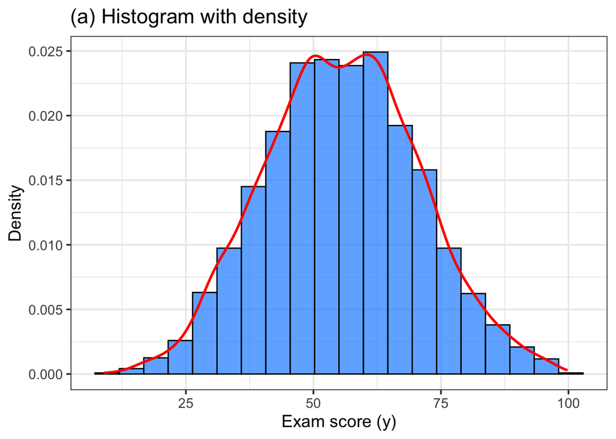

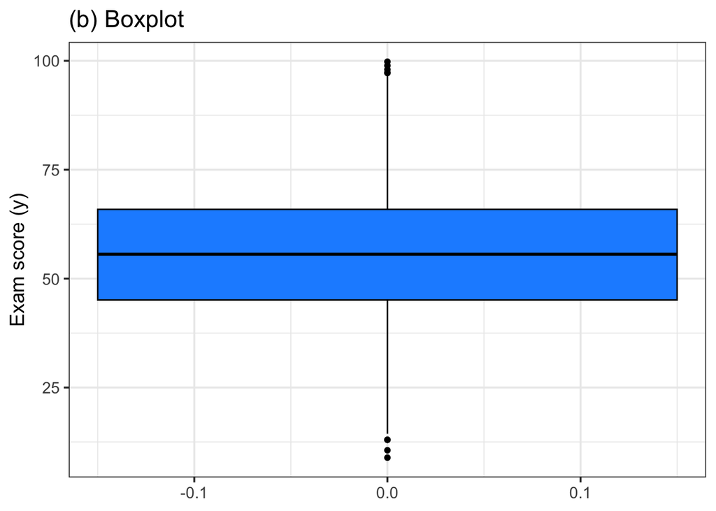

Distribution of exam score (y)

```r
# Histogram with density
ggplot(data_clean, aes(x = y)) +
  geom_histogram(aes(y = after_stat(density)), bins = 20,
                 color = "black", fill = "dodgerblue", alpha = 0.7) +
  geom_density(color = "red", linewidth = 1) +
  labs(x = "Exam score (y)", y = "Density", title = "(a) Histogram with density")+
  theme_bw(base_size = 14)

# Boxplot
ggplot(data_clean, aes(y = y)) +
  geom_boxplot(fill = "dodgerblue", color = "black", width = 0.3) +
  labs(y = "Exam score (y)", title = "(b) Boxplot")  +
  theme_bw(base_size = 14)
```

The distribution of exam scores is **approximately symmetric, with a slight right skew**. While a few higher values are visible, **no extreme outliers** are observed. As a result, no transformation of the response variable is required, and exam scores can be used **directly** in the linear regression models.

## 3.3 Relationships with Quantitative Predictors

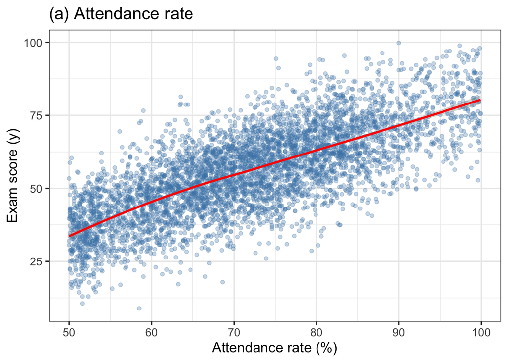

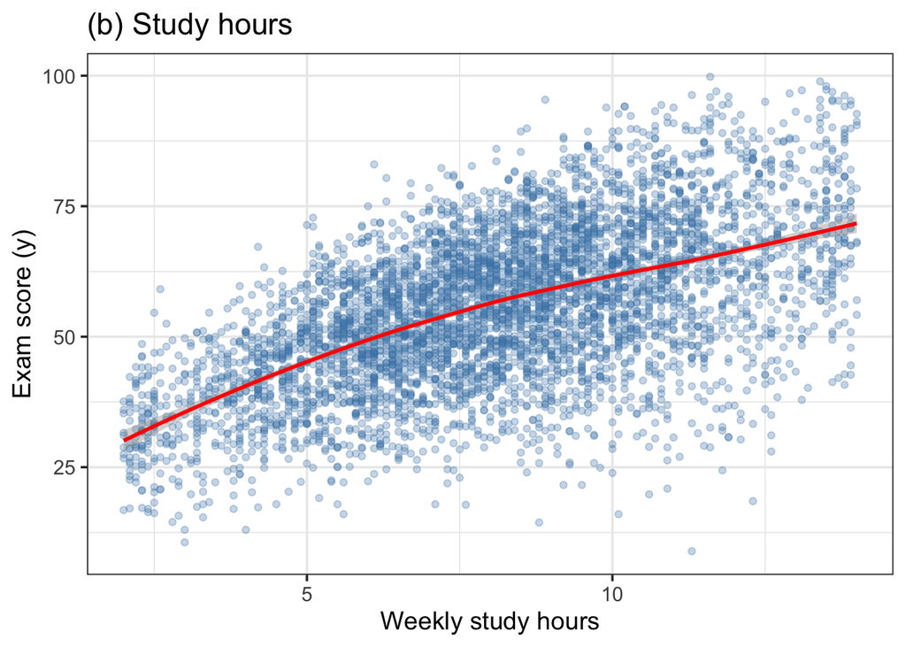

Exam score vs quantitative predictors (LOESS smooth)

**Comment on linearity**

Overall, LOESS curves suggest that linear specifications are reasonable for the quantitative predictors.

## 3.4 Relationships with Categorical Predictors

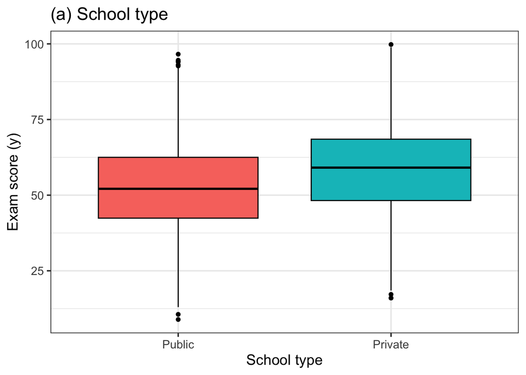

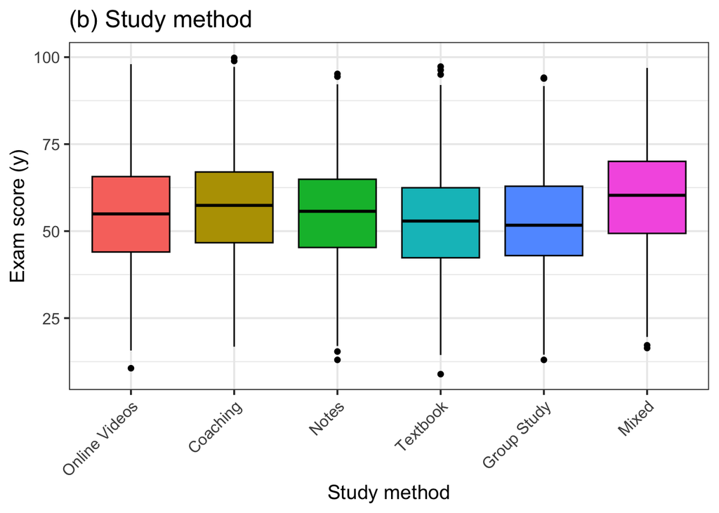

Exam score vs selected categorical predictors

Exam scores **differ across school types and study methods**. In particular, students attending private schools and those using certain study methods tend to achieve higher scores, which motivates the inclusion of these categorical variables in the regression models.

## 3.5 Relationships with Ordinal Predictors

[figure not shown]

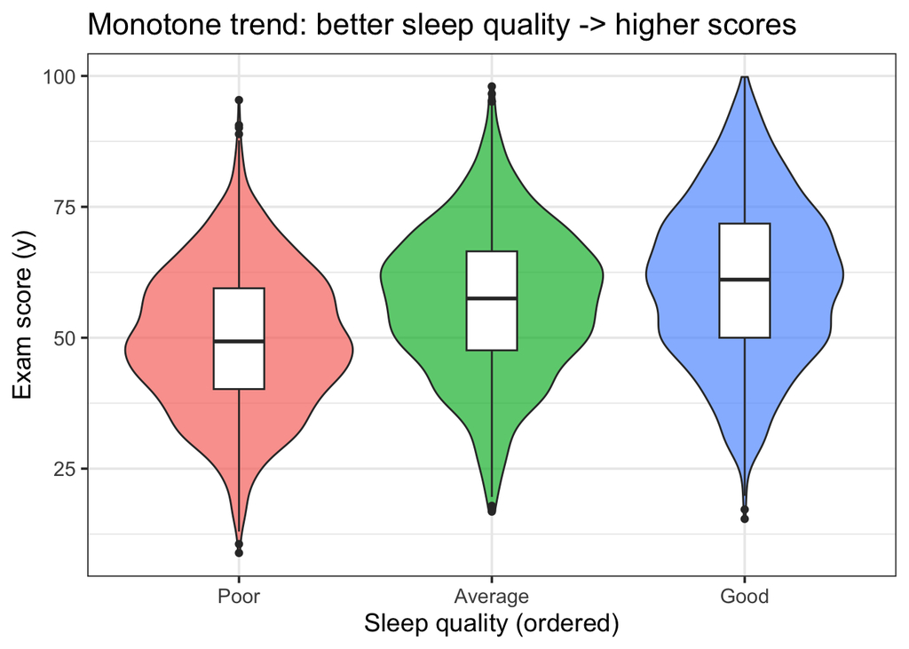

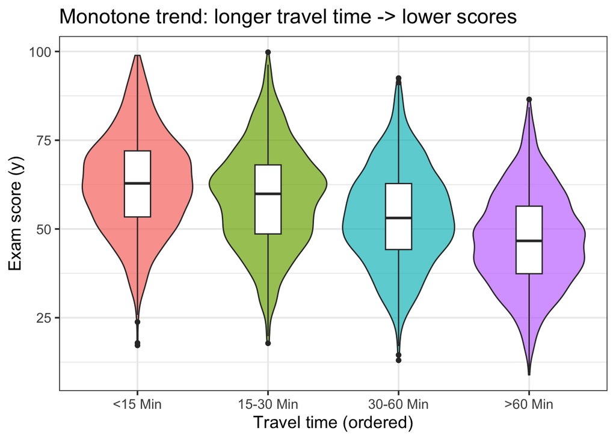

## 3.6 Associations Between Predictors

### 3.6.1 Correlation Matrix (Quantitative Variables)

```r
# Correlation matrix for quantitative predictors
quant_vars <- data_clean %>% select(y, age, study_hrs, sleep_hrs, attend_pct)
cor_matrix <- cor(quant_vars)
round(cor_matrix, 2)
```

```
##                y   age study_hrs sleep_hrs attend_pct
## y           1.00 -0.05      0.57      0.41       0.74
## age        -0.05  1.00      0.00     -0.14      -0.03
## study_hrs   0.57  0.00      1.00     -0.14       0.53
## sleep_hrs   0.41 -0.14     -0.14      1.00       0.32
## attend_pct  0.74 -0.03      0.53      0.32       1.00
```

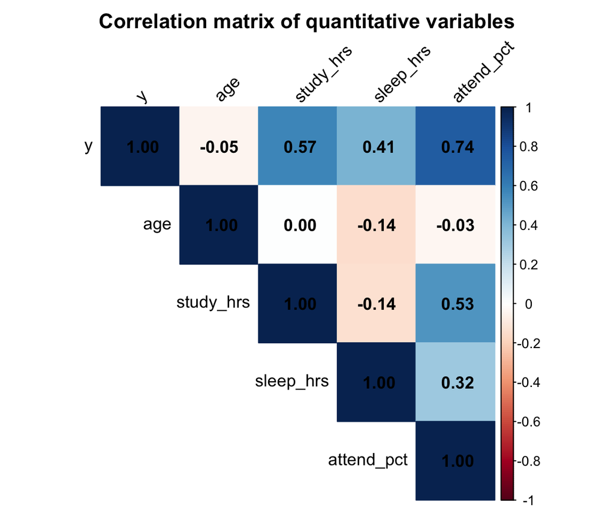

Correlation Matrix of Quantitative Variables

```r
# Visualize correlation matrix
corrplot(cor_matrix, method = "color", type = "upper",
         addCoef.col = "black", tl.col = "black", tl.srt = 45,
         title = "Correlation matrix of quantitative variables",
         mar = c(0, 0, 2, 0))
```

### 3.6.2 Associations Between Categorical Variables

```r
# Association between categorical predictors (example: school_type vs web_access)
table(data_clean$school_type, data_clean$web_access)
```

```
##
##             No  Yes
##   Public   619 1895
##   Private  367 2119
```

```r
chisq.test(data_clean$school_type, data_clean$web_access)
```

```
##
##  Pearson's Chi-squared test with Yates' continuity correction
##
## data:  data_clean$school_type and data_clean$web_access
## X-squared = 76.13, df = 1, p-value < 2.2e-16
```

```r
# Association between categorical predictors (parent_educ vs school_type)
table(data_clean$parent_educ, data_clean$school_type)
```

```
##
##                   Public Private
##   No Formal          717     354
##   High School        426     310
##   Graduate           380     356
##   Post Graduate 1    352     471
##   Post Graduate 2    305     370
##   PHD                334     625
```

### 3.6.3 Mixed Associations

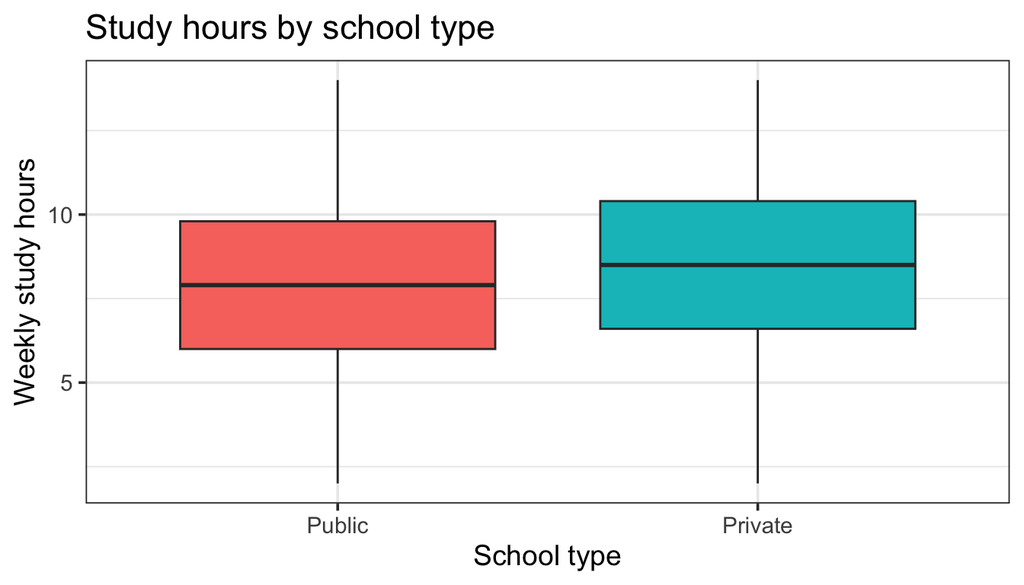

Study Hours by School Type

```r
# Example: study_hrs by school_type
ggplot(data_clean, aes(x = school_type, y = study_hrs, fill = school_type)) +
  geom_boxplot() +
  labs(x = "School type", y = "Weekly study hours",
       title = "Study hours by school type") +
  theme_bw(base_size = 14) +
  theme(legend.position = "none")
```

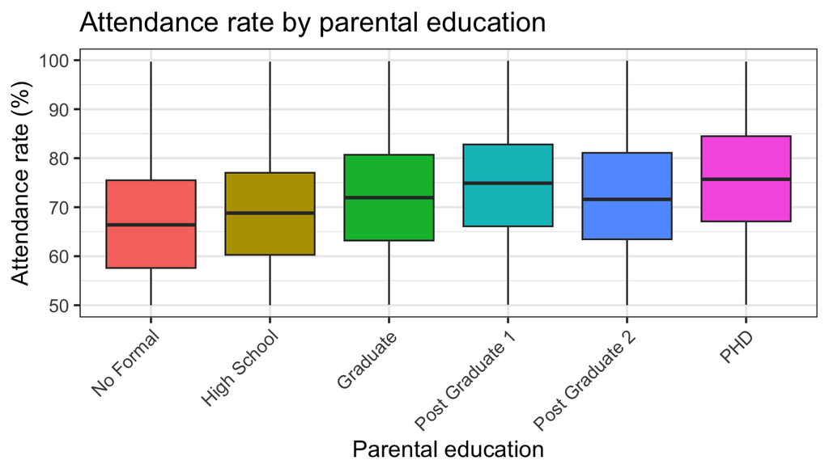

Attendance Rate by Parental Education

```r
# Example: attend_pct by parent_educ
ggplot(data_clean, aes(x = parent_educ, y = attend_pct, fill = parent_educ)) +
  geom_boxplot() +
  labs(x = "Parental education", y = "Attendance rate (%)",
       title = "Attendance rate by parental education") +
  theme_bw(base_size = 14) +
  theme(legend.position = "none", axis.text.x = element_text(angle = 45, hjust = 1))
```

To put it in a nutshell, these associations should be monitored in the modeling stage but do not suggest severe multicollinearity issues.

### 3.6.4 EDA Summary

**3) Interaction hypotheses** The exploratory analysis motivates testing a small number of interaction effects. In particular, the impact of study hours may depend on attendance rate, and the effect of school type may vary with parental education.

**4) Potential collinearity** Moderate correlations are observed between some predictors, notably between attendance rate and study hours. Socioeconomic variables also appear partially related (parent_educ, school_type, web_access). However, these associations do not suggest severe multicollinearity concerns and will be monitored in the modeling stage.

# 4 Building Regression Models

The objective of the model selection process is to *identify a parsimonious linear regression model* that explains students’ exam performance while maintaininig *interpretability, statistical validity, and predictive performance*.

## 4.1 Simple Linear Regressions

Before building multiple regression models, we first examine the relationship between the response variable `y` and each predictor individually.This helps us:  
- Identify which predictors have the **strongest** individual association with exam scores  
- Detect predictors with **negligible explanatory power** (candidates for exclusion)  
- Inform our strategy for building multiple regression models

```r
# Quantitative predictors
m_age    <- lm(y ~ age, data = data_clean)
m_study  <- lm(y ~ study_hrs, data = data_clean)
m_sleep  <- lm(y ~ sleep_hrs, data = data_clean)
m_attend <- lm(y ~ attend_pct, data = data_clean)

# Categorical predictors
m_sexe      <- lm(y ~ sexe, data = data_clean)
m_school    <- lm(y ~ school_type, data = data_clean)
m_parent    <- lm(y ~ parent_educ, data = data_clean)
m_sleepqual <- lm(y ~ sleep_qual, data = data_clean)
m_trav      <- lm(y ~ trav_time, data = data_clean)
m_extra     <- lm(y ~ extra_act, data = data_clean)
m_web       <- lm(y ~ web_access, data = data_clean)
m_method    <- lm(y ~ study_method, data = data_clean)
```

The table below summarizes the results of the **simple regression models**.

```r
# Create summary table
simple_models <- list(
  attend_pct = m_attend, study_hrs = m_study, sleep_hrs = m_sleep, age = m_age,
  parent_educ = m_parent, sleep_qual = m_sleepqual, trav_time = m_trav,
  school_type = m_school, web_access = m_web, extra_act = m_extra,
  study_method = m_method, sexe = m_sexe
)

simple_reg_table <- data.frame(
  Predictor = names(simple_models),
  R2 = round(sapply(simple_models, function(m) summary(m)$r.squared), 4),
  Adj_R2 = round(sapply(simple_models, function(m) summary(m)$adj.r.squared), 4)
)
simple_reg_table <- simple_reg_table[order(-simple_reg_table$R2), ]
rownames(simple_reg_table) <- NULL

simple_reg_table
```

| Predictor | R2 | Adj_R2 |
| --- | --- | --- |
| attend_pct | 0.5497 | 0.5496 |
| study_hrs | 0.3252 | 0.3250 |
| trav_time | 0.1694 | 0.1689 |
| sleep_hrs | 0.1685 | 0.1684 |
| parent_educ | 0.1033 | 0.1024 |
| sleep_qual | 0.1030 | 0.1026 |
| extra_act | 0.0739 | 0.0737 |
| school_type | 0.0404 | 0.0402 |
| web_access | 0.0396 | 0.0394 |
| study_method | 0.0249 | 0.0239 |

[output cut: 2 more lines]

**Observations:**

- `attend_pct` explains ~55% of variance alone (strongest predictor)
- `study_hrs` explains ~32% of variance
- `sexe` has near-zero R² → **excluded from multiple regression**
- `extra_act` and `study_method` show low explanatory power (low R²)

## 4.2 Multiple linear regression models

```r
# Model 0: Baseline with quantitative predictors only
mod0 <- lm(y ~ attend_pct + study_hrs + age + sleep_hrs, data = data_clean)

# Model 1: Add key categorical/ordinal predictors supported by EDA
mod1 <- lm(y ~ attend_pct + study_hrs + age + sleep_hrs +
             parent_educ + sleep_qual + trav_time +
             school_type + web_access,
           data = data_clean)

# Model 2: Add extra_act and study_method
mod2 <- lm(y ~ attend_pct + study_hrs + age + sleep_hrs +
             parent_educ + sleep_qual + trav_time +
             school_type + web_access +
             extra_act + study_method,
           data = data_clean)

# Model 3: Test ONE interaction hypothesis
# Hypothesis: The effect of study hours on exam score may depend on attendance rate.
mod3 <- lm(y ~ attend_pct * study_hrs + age + sleep_hrs +
             parent_educ + sleep_qual + trav_time +
             school_type + web_access,
           data = data_clean)
```

**Model justification:**

- Candidate models are constructed incrementally, starting from a baseline specification and progressively adding groups of predictors motivated by exploratory analysis.

| Model | Description | Variables |
| --- | --- | --- |
| mod0 | Baseline | 4 quantitative predictors |
| mod1 | Main effects | + 5 categorical/ordinal predictors (9 total) |
| mod2 | Extended | + extra_act + study_method (11 total) |
| mod3 | Interaction | mod1 + attend_pct × study_hrs |

### 4.2.1 Interaction Hypothesis and Transformations

- We further test **one interaction hypothesis**: the effect of study hours on exam performance may depend on attendance rate, with higher attendance potentially enhancing the returns to study time.

This hypothesis is **motivated** by the idea that study time may be more productive for students with higher attendance.

```r
anova(mod1, mod3)
```

|  | Res.Df | RSS | Df | Sum of Sq | F | Pr(>F) |
| --- | --- | --- | --- | --- | --- | --- |
| 1 | 4983 | 333285.8 | NA | NA | NA | NA |
| 2 | 4982 | 333112.2 | 1 | 173.549 | 2.595585 | 0.1072252 |

**Result:** The interaction term `attend_pct:study_hrs` is **not statistically significant** (p ≈ 0.11). Following the principle of parsimony, we do not retain interaction terms.

**What about transformations ?**

- Regarding potential **transformations**, exploratory analysis and diagnostic checks indicate that the relationships are approximately linear and that the response distribution is reasonably **symmetric**. Therefore, **no transformation** was applied in order to preserve **interpretability**.

## 4.3 Model Comparison

```r
# Model performance table (Adj R², AIC, BIC)
tab_models <- bind_rows(
  model_performance(mod0) |> mutate(Model = "mod0"),
  model_performance(mod1) |> mutate(Model = "mod1"),
  model_performance(mod2) |> mutate(Model = "mod2"),
  model_performance(mod3) |> mutate(Model = "mod3")
) |>
  select(Model,R2, R2_adjusted, AIC, BIC) |>
  arrange(AIC)

tab_models
```

| Model | R2 | R2_adjusted | AIC | BIC |
| --- | --- | --- | --- | --- |
| mod2 | 0.7110534 | 0.7097761 | 35153.45 | 35309.86 |
| mod3 | 0.7064433 | 0.7054416 | 35222.59 | 35346.42 |
| mod1 | 0.7062903 | 0.7053472 | 35223.20 | 35340.51 |
| mod0 | 0.6756064 | 0.6753466 | 35696.03 | 35735.13 |

```r
# Nested F-tests (inferential criterion)
ftests <- bind_rows(
  anova(mod0, mod1) |> as.data.frame() |> mutate(Comparison = "mod0 vs mod1"),
  anova(mod1, mod2) |> as.data.frame() |> mutate(Comparison = "mod1 vs mod2"),
  anova(mod1, mod3) |> as.data.frame() |> mutate(Comparison = "mod1 vs mod3")
) |>
  filter(!is.na(`Pr(>F)`)) |>
  select(Comparison, Df, F, `Pr(>F)`)

ftests
```

|  | Comparison | Df | F | Pr(>F) |
| --- | --- | --- | --- | --- |
| 2...1 | mod0 vs mod1 | 12 | 43.381277 | 1.883893e-98 |
| 2...2 | mod1 vs mod2 | 6 | 13.673717 | 1.829987e-15 |
| 2...3 | mod1 vs mod3 | 1 | 2.595585 | 1.072252e-01 |

## 4.4 Final Model Selection

```r
final_model <- mod1
```

# 5 Model diagnostics

Once, we have our model we must check the normality of our residuals. To do so, we use graphics and tests to have as many points of view as possible.

## 5.1 Linearity of our model

**Residual vs fitted value**

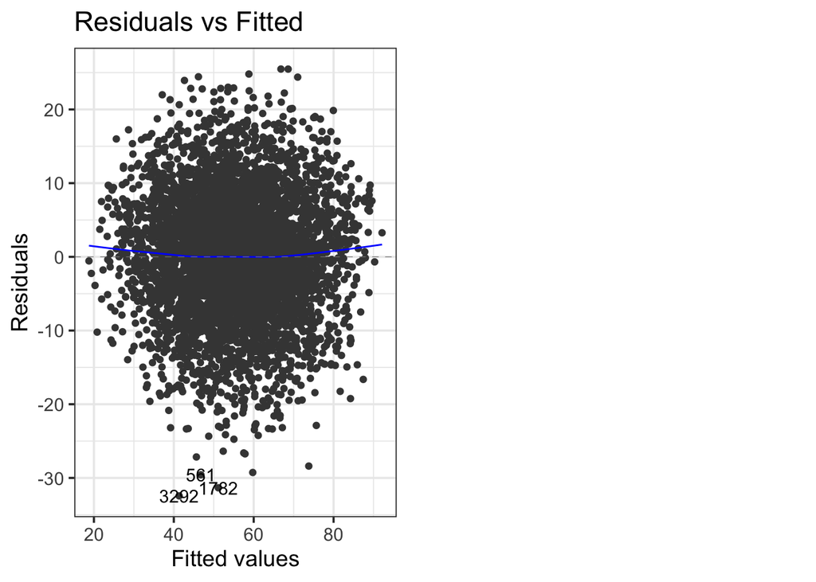

```r
autoplot(mod1, which = 1) +
  theme_bw(base_size = 14)
```

The residuals are **randomly scattered around zero with no obvious pattern**,supporting the fact that our residuals are well centered and the linearity of our model.

**Residual vs quantitative predictors**

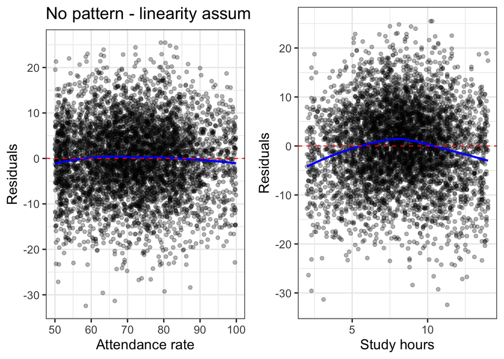

```r
library(gridExtra)

g1 <- data_clean |>
  ggplot(aes(x = attend_pct, y = resid(mod1))) +
  geom_point(alpha = 0.3) +
  geom_smooth(method = "loess", se = FALSE, color = "blue") +
  geom_hline(yintercept = 0, linetype = "dashed", color = "red") +
  labs(x = "Attendance rate", y = "Residuals",
       title = "No pattern - linearity assumption satisfied") +
  theme_bw(base_size = 14)

g2 <- data_clean |>
  ggplot(aes(x = study_hrs, y = resid(mod1))) +
  geom_point(alpha = 0.3) +
  geom_smooth(method = "loess", se = FALSE, color = "blue") +
  geom_hline(yintercept = 0, linetype = "dashed", color = "red") +
  labs(x = "Study hours", y = "Residuals") +
  theme_bw(base_size = 14)
grid.arrange(g1, g2, ncol = 2)
```

**Residual vs omitted variables**

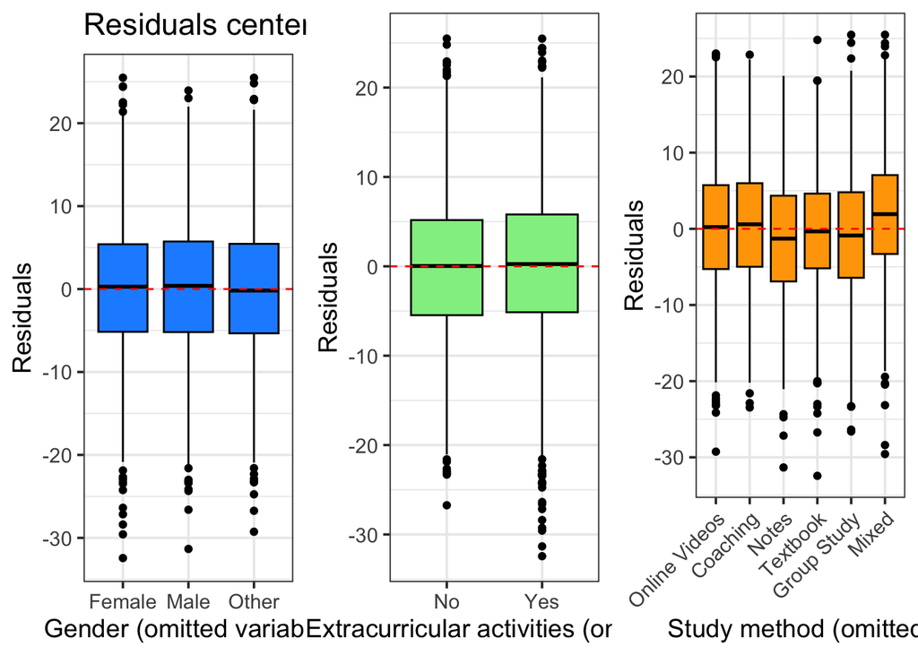

```r
library(gridExtra)

g1 <- ggplot(data_clean, aes(x = sexe, y = resid(mod1))) +
  geom_boxplot(fill = "dodgerblue", color = "black") +
  geom_hline(yintercept = 0, linetype = "dashed", color = "red") +
  labs(x = "Gender (omitted variable)", y = "Residuals",
       title = "Residuals centered at zero for all groups") +
  theme_bw(base_size = 14)

g2 <- ggplot(data_clean, aes(x = extra_act, y = resid(mod1))) +
  geom_boxplot(fill = "lightgreen", color = "black") +
  geom_hline(yintercept = 0, linetype = "dashed", color = "red") +
  labs(x = "Extracurricular activities (omitted)", y = "Residuals") +
  theme_bw(base_size = 14)

g3 <-ggplot(data_clean, aes(x = study_method, y = resid(mod1))) +
  geom_boxplot(fill = "orange", color = "black") +
  geom_hline(yintercept = 0, linetype = "dashed", color = "red") +
  labs(x = "Study method (omitted)", y = "Residuals") +
  theme_bw(base_size = 14) +
  theme(axis.text.x = element_text(angle = 45, hjust = 1))

g4 <-

  grid.arrange(g1, g2, g3, ncol = 3)
```

[figure not shown]

```r
autoplot(mod1, which = 3) +                                              theme_bw(base_size = 14)
```

```r
library(car)

set.seed(42)
durbinWatsonTest(mod1)
```

```
##  lag Autocorrelation D-W Statistic p-value
##    1    -0.003581903      2.006766   0.836
##  Alternative hypothesis: rho != 0
```

The p-value is bigger than 0.05, so our observations are **uncorrelated**.

**Breusch-Pagan test**

```r
bp_result <- bptest(mod1)
bp_result
```

```
##
##  studentized Breusch-Pagan test
##
## data:  mod1
## BP = 19.129, df = 16, p-value = 0.262
```

The Scale-Location plot shows a relatively flat trend, suggesting that the variance of residuals is approximately constant. And, the test gives a big p-value (> 0.05). So, both confirm the **homoscedasticity assumption**.

## 5.4 Normality assumption

**Shapiro test**

```r
set.seed(42)
resid_sample <- sample(resid(mod1), size = min(5000, length(resid(mod1))))
shapiro_result <- shapiro.test(resid_sample)
shapiro_result
```

```
##
##  Shapiro-Wilk normality test
##
## data:  resid_sample
## W = 0.99878, p-value = 0.0008631
```

**QQ plot**

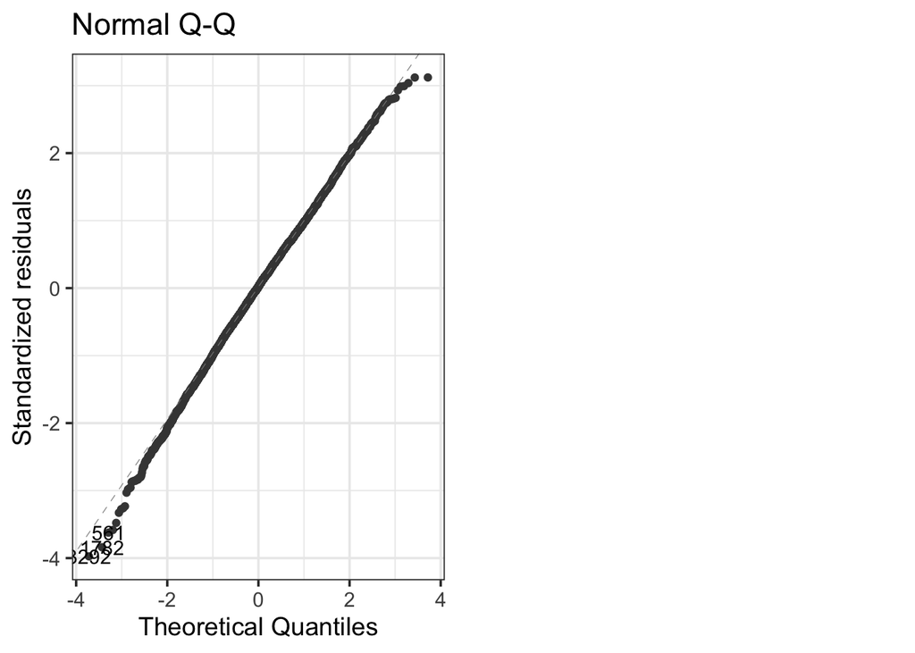

```r
autoplot(mod1, which = 2) +
  theme_bw(base_size = 14)
```

Although the **Shapiro-Wilk test** rejects the normality of the residuals (p-value < 0.05), the graphical analysis (**QQ-plot**) suggests an approximately Gaussian distribution, consistent with the normality assumption of our model.

## 5.5 Outlier dectection

**Cook’s distance**

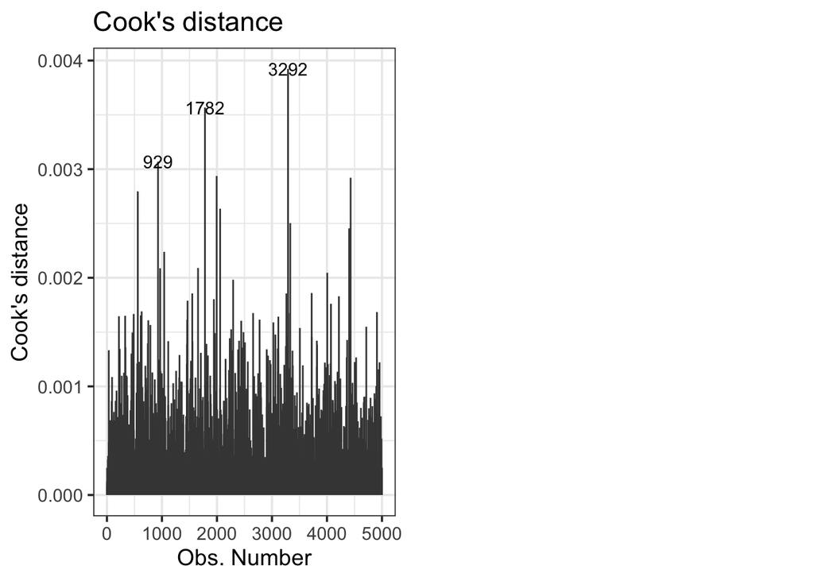

```r
autoplot(mod1, which = 4) +
  theme_bw(base_size = 14)
```

No observation has a **Cook’s distance** values higher than 1. So, our model has no outiler.

# 6 Interpretation and inference

## 6.1 Final Model Equation

The final model is a multiple linear regression that brings together the main quantitative and categorical variables identified during the exploratory analysis.

```r
final_model <- mod1

summary(final_model)
```

```
##
## Call:
## lm(formula = y ~ attend_pct + study_hrs + age + sleep_hrs + parent_educ +
##     sleep_qual + trav_time + school_type + web_access, data = data_clean)
##
## Residuals:
##     Min      1Q  Median      3Q     Max
## -32.433  -5.245   0.188   5.550  25.482
##
## Coefficients:
##                             Estimate Std. Error t value Pr(>|t|)
## (Intercept)                -18.49180    1.81615 -10.182  < 2e-16 ***
## attend_pct                   0.46691    0.01303  35.839  < 2e-16 ***
## study_hrs                    2.16070    0.05681  38.033  < 2e-16 ***
## age                          0.08799    0.08093   1.087 0.276985
## sleep_hrs                    2.44040    0.15793  15.452  < 2e-16 ***
## parent_educHigh School       0.87972    0.39429   2.231 0.025717 *
## parent_educGraduate          1.14106    0.40296   2.832 0.004649 **
## parent_educPost Graduate 1   2.22565    0.39761   5.598 2.29e-08 ***
## parent_educPost Graduate 2   2.03245    0.41318   4.919 8.97e-07 ***
## parent_educPHD               2.04704    0.39019   5.246 1.62e-07 ***
## sleep_qualAverage            4.28619    0.34768  12.328  < 2e-16 ***
## sleep_qualGood               4.41721    0.47696   9.261  < 2e-16 ***
## trav_time15-30 Min          -0.43189    0.33114  -1.304 0.192210
## trav_time30-60 Min          -1.79646    0.33668  -5.336 9.93e-08 ***
## trav_time>60 Min            -3.58263    0.34970 -10.245  < 2e-16 ***
## school_typePrivate           2.13787    0.23882   8.952  < 2e-16 ***
## web_accessYes                1.00718    0.30447   3.308 0.000946 ***
## ---
## Signif. codes:  0 '***' 0.001 '**' 0.01 '*' 0.05 '.' 0.1 ' ' 1
##
## Residual standard error: 8.178 on 4983 degrees of freedom
## Multiple R-squared:  0.7063, Adjusted R-squared:  0.7053
## F-statistic: 748.9 on 16 and 4983 DF,  p-value: < 2.2e-16
```

**Final model equation:**

$$y = \beta_0 + \beta_1 \cdot
\text{attend\_pct} + \beta_2 \cdot \text{study\_hrs} + \beta_3 \cdot
\text{age} + \beta_4 \cdot \text{sleep\_hrs} + \ldots +
\varepsilon$$

**Reference categories:**

- `parent_educ`: “No Formal”
- `sleep_qual`: “Poor”
- `trav_time`: “<15 Min”
- `school_type`: “Public”
- `web_access`: “No”